# Representativity measure - working paper

Rasmus Bordoy, Thomas Gerds, Nina Føns Johnsen, Sidsel Marie Bernt Jørgensen

September 2023

In regards to studying participation in a survey by The Danish Heart Foundation called Life With A Heart disease, then the following subject has become of interest.

**Description of subject and theme**

The subject/theme is to find some measure that speaks of the representativity amongst the participants in the survey. The notion of representativity is somewhat arbitrary, since it does not have a clear statistical meaning. In short, the interest is to investigate to what extent the proportions of groups within a dataset (respondants only) are equal.

Some representativity measures will be presented through examples, first for categorical groups, and then later an attempt to incorporate continuous variables into the measure will be made.

**Examples**

**Example 1** - *Contribution of disjoint groups falling below the overall response rate**

In this example the intention is to measure how much the response rate within groups differs from the overall response rate.

Assume that there are two stratifications in the data meaning that there is only one covariate with two groups in the following setup.

The difference in response rate is measured whenever the response rate falls below the $\underline{\text{overall response rate}}$, since some may argue that an over-representation within a group doesn’t cause problems nor more potential.

Let ${p}_{\text{overall}} = \frac{\sum_{i=1}^{N} \pi_i}{N}$ be the overall response rate for a response indicator $\pi_i \in \{0,1\}$. Then let $g_1$ and $g_2$ be two disjoint groups within the data, say male and female, and let ${p}_{g_1}$ and ${p}_{g_2}$ be their response rates. The categorical response rate is defined as
$${p}_{g_1} = \frac{\sum_{i=1}^{N_{g_1}} \pi_i
}{N_{g_1}},$$
where $N_{g_1}$ is the number of records within group $1$.

Allowing the contribution from response rates within groups only being present whenever the response rates fall below ${p}_{\text{overall}}$, then the following measure measures to which extent the response rates fall below the overall response rate

$$\begin{align}
\text{R} & = \frac{{p}_{g_1} 1_{ \{ {p}_{g_1}
<{p}_{\text{overall}} \} }+
{p}_{\text{overall}} 1_{ \{{p}_{g_1} \geq {p}_{\text{overall}} \}
}
\,\,\,\,+
\,\,\,\,
{p}_{g_2} 1_{ \{
{p}_{g_2} <{p}_{\text{overall}} \}
}+{p}_{\text{overall}}
1_{ \{ {p}_{g_2} \geq {p}_{\text{overall}} \}} }
{2 \cdot {p}_{\text{overall}}} \\
& = 1+\frac{ \frac{1}{2} \left\{ 1_{ \{ p_{g_1} <
p_{\text{overall}} \} } \left( p_{g_1} - p_{\text{overall}} \right) \,\,
+ \,\, 1_{ \{ p_{g_2} < p_{\text{overall}} \} } \left( p_{g_2} -
p_{\text{overall}} \right) \right\} }{p_{\text{overall}}},
\end{align}$$
where $-1 \leq 1_{ \{ p_{g_1} < p_{\text{overall}} \} } \left( p_{g_1} - p_{\text{overall}} \right) \leq 0$ leading to $R \in [0,1]$. This leads to an average representativity of the groups in terms of response, and it is measured from a perspective that reaching $1$, or say $100 \%$, is only a possibility if the response rates (not the number of responses) are perfectly split across the groups.

A covariate with $K$ groups has the following categorical representativity measure

$$\begin{align}
\text{R} & =
1+\frac{ \frac{1}{K} \left\{ \sum_{i=1}^K 1_{ \{ p_{g_i} <
p_{\text{overall}} \} } \left( p_{g_i} - p_{\text{overall}}
\right) \right\} }{p_{\text{overall}}}.
\end{align}$$

**Example 2** - *Contribution of continuous covariate falling below the overall response rate**

Considering contributions of covariates that are continuous, then a different strategy has to be considered in order to find the representativity and balance though the values the covariate takes in regards of response rates. Assuming the continuous covariate is age, then it is of interest to consider how the response rates are distributed along the values the age covariate takes and then measure how this behaviour is compared to the overall response rate. Response rates above the overall response rate are, again, assumed to not contribute to the representativity any more than the overall response rate, but contributions below the overall response rate will be “punished” in regards to lacking representativity.

The presented representativity measure will represent the balance in the response for a continuous covariate, but it does not represent which values in the covariate are either balanced or unbalanced. In other words, the representativity of the continuous covariate is combined into a single number representing the overall average representativity within the continuous covariate.

Consider the following figure

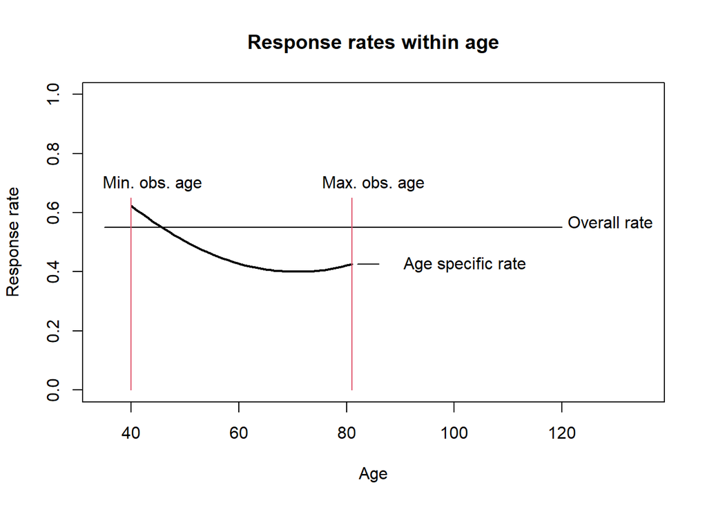

```r
obs_age <- seq(from=40,to=81,by=1)
pot_age <- seq(from=35,to=120,by=1)
overall_rate <- 0.55
age_specific_rate <- -sin(obs_age/45)+1.4

plot(x=pot_age,y=rep(overall_rate,length(pot_age)),type="l",ylim=c(0,1),xlim=c(min(pot_age),max(pot_age)+15),xlab="Age",ylab="Response rate",main="Response rates within age")

text(x=129,y=0.57,"Overall rate")

lines(y=age_specific_rate,x=obs_age,col=9,lwd=2)
lines(y=rep(age_specific_rate[length(obs_age)],10),x=seq(from=max(obs_age)+1,to=max(obs_age)+5,length=10))
text(y=age_specific_rate[length(obs_age)],x=102,"Age specific rate")

lines(x=rep(40,10),y=seq(from=0,to=0.65,length=10),col=2)
text(x=min(obs_age)+4,y=0.7,"Min. obs. age")

lines(x=rep(max(obs_age),10),y=seq(from=0,to=0.65,length=10),col=2)
text(x=max(obs_age)+4,y=0.7,"Max. obs. age")
```

In the figure above it is seen that the response rate for a given age on the x-axis changes throughout. The overall response rate is $0.55$, whilst the age specific response rate follows some arbitrary given sine function chosen for illustration.

The area below the line with age specific rates whilst being below the overall rate will be the contribution of response rate from the age covariate in general, and the area between the overall rate and age specific rate whenever the latter is below the overall rate will be the contribution to “loss of response”. The following figure illustrates this.

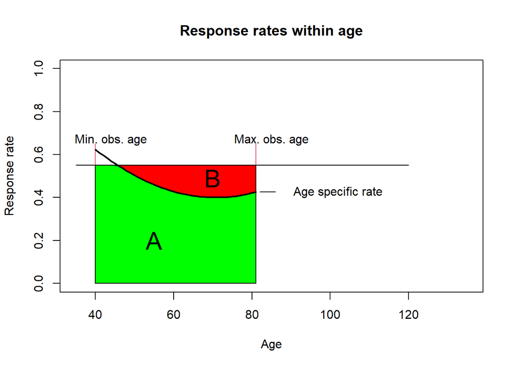

```r
obs_age <- seq(from=40,to=81,by=1)
pot_age <- seq(from=35,to=120,by=1)
overall_rate <- 0.55
age_specific_rate <- -sin(obs_age/45)+1.4
plot(x=pot_age,y=rep(overall_rate,length(pot_age)),type="l",ylim=c(0,1),xlim=c(min(pot_age),max(pot_age)+15),xlab="Age",ylab="Response rate",main="Response rates within age")


lines(y=age_specific_rate,x=obs_age,col=9,lwd=2)
lines(y=rep(age_specific_rate[length(obs_age)],10),x=seq(from=max(obs_age)+1,to=max(obs_age)+5,length=10))
text(y=age_specific_rate[length(obs_age)],x=102,"Age specific rate")
lines(x=rep(40,10),y=seq(from=0,to=0.65,length=10),col=2)
text(x=min(obs_age)+4,y=0.67,"Min. obs. age")

lines(x=rep(max(obs_age),10),y=seq(from=0,to=0.65,length=10),col=2)
text(x=max(obs_age)+4,y=0.67,"Max. obs. age")


polygon(c(min(obs_age), max(obs_age), max(obs_age),min(obs_age)), c(0, 0,0.55,0.55), col="red")

polygon(c(obs_age, max(obs_age), 40),
        c(ifelse(-sin(obs_age/45)+1.4>0.55,0.55,-sin(obs_age/45)+1.4), 0,0 ), col="green")

text(55,0.2,"A",cex=2)
text(70,0.49,"B",cex=2)
lines(y=age_specific_rate,x=obs_age,col=9,lwd=2)
```

The balance/representativity within the continuous age covariate can then be measured as
$$R = \frac{A}{A+B}$$

The areas A and B are found by integrating the overall response rate over the observed age values.
$$A+B = \int_{\text{age}} p_{\text{overall}} \, ds = p_{\text{overall}}
\left( \max \text{age} - \min \text{age} \right)$$
Let the age-specific response rate be given as a function of age $p_{ \text{ age} }(s)$. The area A can be found as

$$\begin{align}
A & = \int_{\text{age}} p_{\text{ age}}( s) 1_{ \{ p_{\text{ age}}(
s) < p_{\text{overall}} \} } + p_{\text{overall}} 1_{ \{ p_{\text{
age}} \geq p_{\text{overall}} \} } \, ds \\
&= \int_{\text{age}} p_{\text{overall}}+1_{ \{ p_{\text{ age}}( s)
< p_{\text{overall}} \} }\left(p_{\text{ age}}( s) -
p_{\text{overall}} \right) \, ds \\
&= p_{\text{overall}} \left( \max \text{age} - \min \text{age}
\right) +
\int_{\text{age}}1_{ \{ p_{\text{ age}}( s) < p_{\text{overall}} \}
}\left(p_{\text{ age}}( s) - p_{\text{overall}} \right) \, ds,
\end{align}$$
where $\int_{\text{age}}1_{ \{ p_{\text{ age}}( s) < p_{\text{overall}} \} }\left(p_{\text{ age}}( s) - p_{\text{overall}} \right) \, ds \leq 0$.

The representativity measure for a continuous covariate can then be given as
$$\begin{align}
R &= \frac{A}{A+B} \\
&= \frac{p_{\text{overall}} \left( \max \text{age} - \min \text{age}
\right) +
\int_{\text{age}}1_{ \{ p_{\text{ age}}( s) < p_{\text{overall}} \}
}\left(p_{\text{ age}}( s) - p_{\text{overall}} \right) \, ds}{
p_{\text{overall}} \left( \max \text{age} - \min \text{age} \right)}\\
& = 1+\frac{
\int_{\text{age}}1_{ \{ p_{\text{ age}}( s) < p_{\text{overall}} \}
}\left(p_{\text{ age}}( s) - p_{\text{overall}} \right) \, ds}{
p_{\text{overall}} \left( \max \text{age} - \min \text{age} \right)}.
\end{align}$$

Sometimes it is more convenient to take integer numbers instead of continuous number and then transform the integral into a sum. Then the expression changes to
$$\begin{align}
R & = 1 + \frac{\sum_{i = \min \text{age}}^{\max \text{age}} 1_{
\{ p_{\text{ age}}( i) < p_{\text{overall}} \} } \left( p_{\text{
age}}( i) - p_{\text{overall}} \right)}{p_{\text{overall}} \left( \max
\text{age} - \min \text{age} \right)},
\end{align}$$

where
$$p_{ \text{ age} }(i) = \frac{
\sum_{j = 1}^{N} 1_{ \{ \text{age}_j = i \} } \pi_j}{ \sum_{j = 1}^{N}
1_{ \{ \text{age}_j = i \} }},$$
and $i$ is a given age value represented as an integer. The discrete version also applies to covariates that have clearly defined orders

$\textbf{NB:}$ Confusion can arise with the presented measure since the age specific response rate is not symmetric around the overall rate. There is a different number of persons for each age which leads to different weights to the overall response rate, and when considering the representativity measure there is no control for a lack of persons within a group, only if there is a lack of persons within a group in regards of responding vs not responding.

**Empty** - Comparing several proportions using the chi square test**

**Simulation study**

A synthetic dataset with $1000$ records and covariates on sex (male, female), area (rural, suburban and urban) and age is generated.

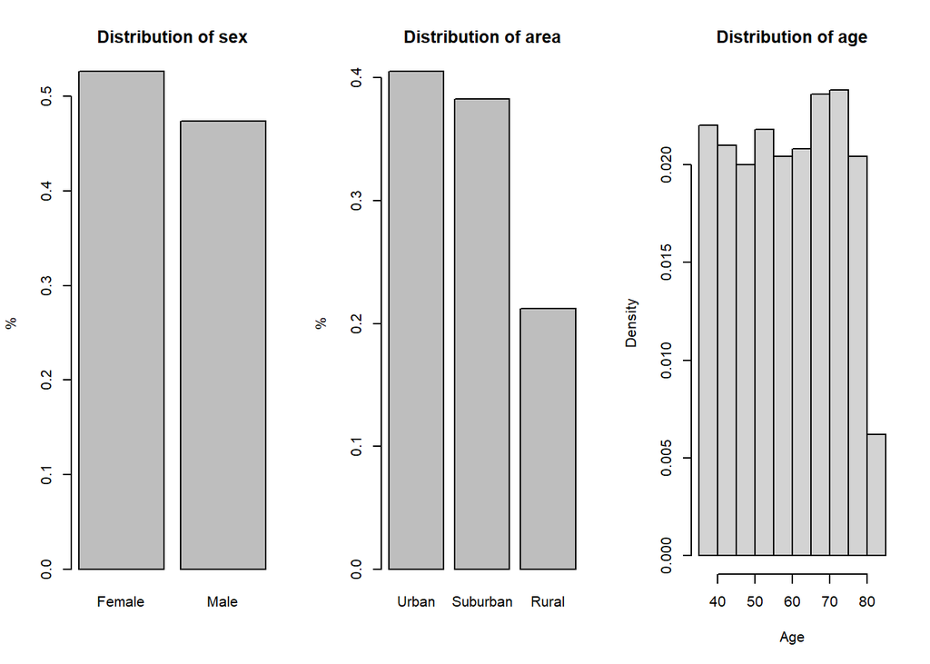

```r
n <- 1000
df <- data.frame(matrix(0,nrow=n,ncol=4))
setDT(df)
#Assign half of the records as male and female
df[,2] <- ifelse(rbinom(n,1,0.5) == 1, "Male","Female")

#Assign 20 percent of the records as living in the rural area, 40 percent in suburban and 40 in urban
df[,3] <- ifelse(rbinom(n,1,0.2)==1,"Rural",ifelse(rbinom(n,1,0.5),"Suburban","Urban"))

#Assign ages randomly from a uniform distribution
df[,4] <- round(runif(n,min=35,max=82),0)

colnames(df) <- c("Response","Sex","Area","Age")

p1 <- (unlist(df[,.N,by=Sex][,2]))/n
names(p1) <- unlist(df[,.N,by=Sex][,1])
p2 <- (unlist(df[,.N,by=Area][,2]))/n
names(p2) <- unlist(df[,.N,by=Area][,1])
par(mfrow=c(1,3))
barplot(p1,main="Distribution of sex",ylab="%")
barplot(p2,main="Distribution of area",ylab="%")
hist(unlist(df[,"Age"]),main="Distribution of age",prob=TRUE,xlab="Age")
```

At the given stage all the responses are $0$. Attributing responses according to a Binomial distribution where the response probabilities are different within interactions of area and sex, then the respresentativity measure can be found.

The following response probabilities are attributed:
$$\begin{array}{|l|l|c|c|c|c|ccc}
\hline \text{Sex} & \text{Area} & p \\
\hline \text{Male} & \text{Rural} & 0.2 \\
\text{Male} & \text{Suburban} & 0.5 \\
\text{Male} & \text{Urban} & 0.4 \\
\text{Female} & \text{Rural} & 0.4 \\
\text{Female} & \text{Suburban} & 0.7 \\
\text{Female} & \text{Urban} & 0.6 \\
\hline
\end{array}$$

No response probabilities are attributed across age and thus the response distribution is assumed to be random.

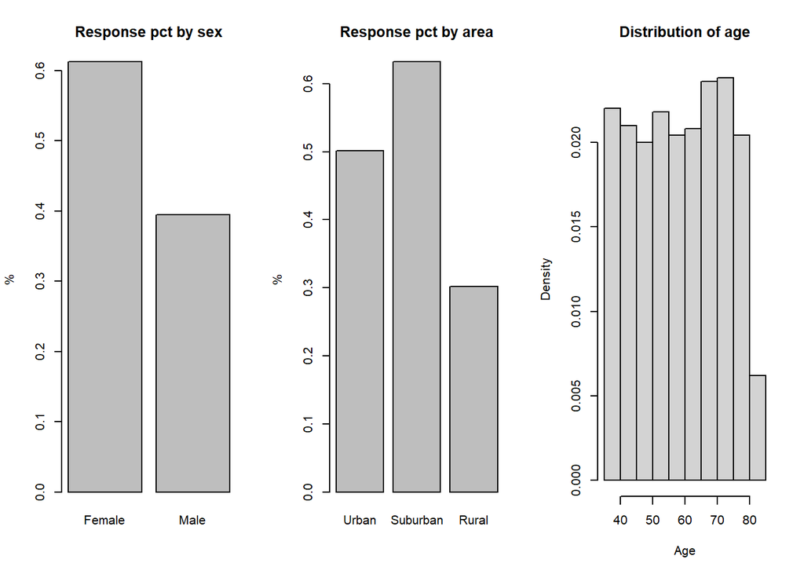

```r
options(width = 300)
df[Sex=="Male" & Area=="Rural"][,1] <- rbinom(dim(df[Sex=="Male" & Area=="Rural"][,1])[1],1,0.2)
df[Sex=="Male" & Area=="Suburban"][,1] <- rbinom(dim(df[Sex=="Male" & Area=="Suburban"][,1])[1],1,0.5)
df[Sex=="Male" & Area=="Urban"][,1] <- rbinom(dim(df[Sex=="Male" & Area=="Urban"][,1])[1],1,0.4)
df[Sex=="Female" & Area=="Rural"][,1] <- rbinom(dim(df[Sex=="Female" & Area=="Rural"][,1])[1],1,0.4)
df[Sex=="Female" & Area=="Suburban"][,1] <- rbinom(dim(df[Sex=="Female" & Area=="Suburban"][,1])[1],1,0.7)
df[Sex=="Female" & Area=="Urban"][,1] <- rbinom(dim(df[Sex=="Female" & Area=="Urban"][,1])[1],1,0.6)

p1 <- (unlist(df[,mean(Response),by=Sex][,2]))
names(p1) <- unlist(df[,mean(Response),by=Sex][,1])

p2 <- (unlist(df[,mean(Response),by=Area][,2]))
names(p2) <- unlist(df[,mean(Response),by=Area][,1])

p3 <- (unlist(df[,mean(Response),by=Age][,2]))
names(p3) <- unlist(df[,mean(Response),by=Age][,1])

par(mfrow=c(1,3))
barplot(p1,main="Response pct by sex",ylab="%")
barplot(p2,main="Response pct by area",ylab="%")
hist(unlist(df[,"Age"]),main="Distribution of age",prob=TRUE,xlab="Age")
```

The representetivity measures are calculated as

```r
seq_rep <- 1+sum(apply(df[,mean(Response),by=Sex],1,function(x){ifelse(as.numeric(x[2])<df[,mean(Response)],as.numeric(x[2])-df[,mean(Response)],0)}))/df[,mean(Response)]
area_rep <- 1+sum(apply(df[,mean(Response),by=Area],1,function(x){ifelse(as.numeric(x[2])<df[,mean(Response)],as.numeric(x[2])-df[,mean(Response)],0)}))/df[,mean(Response)]
p_age <- Vectorize(function(a){
sum(df[Age==a,Response])/nrow(df[Age==a])
})
age_rep <- 1+sum(ifelse(p_age(sort(unlist(unique(df[,"Age"]))))<df[,mean(Response)],p_age(sort(unlist(unique(df[,"Age"]))))-df[,mean(Response)],0))/(df[,mean(Response)]*(max(unlist(unique(df[,"Age"])))-min(unlist(unique(df[,"Age"])))))


sex_rep <- 1+sum(apply(df[,mean(Response),by=Sex],1,function(x){ifelse(as.numeric(x[2])<df[,mean(Response)],as.numeric(x[2])-df[,mean(Response)],0)}))/df[,mean(Response)]
area_rep <- 1+sum(apply(df[,mean(Response),by=Area],1,function(x){ifelse(as.numeric(x[2])<df[,mean(Response)],as.numeric(x[2])-df[,mean(Response)],0)}))/df[,mean(Response)]

p_age <- Vectorize(function(a){
sum(df[Age==a,Response])/nrow(df[Age==a])
})
age_rep <- 1+sum(ifelse(p_age(sort(unlist(unique(df[,"Age"]))))<df[,mean(Response)],p_age(sort(unlist(unique(df[,"Age"]))))-df[,mean(Response)],0))/(df[,mean(Response)]*(max(unlist(unique(df[,"Age"])))-min(unlist(unique(df[,"Age"])))))


print(list("Representativity Sex"=round(sex_rep,4),
     "Representativity Area" = round(area_rep,4),
     "Representativity Age"=round(age_rep,4)))
```

```
## $`Representativity Sex`
## [1] 0.7751
##
## $`Representativity Area`
## [1] 0.5778
##
## $`Representativity Age`
## [1] 0.9089
```

The average representativity is

```r
mean(c(sex_rep,area_rep,age_rep))
```

```
## [1] 0.7539382
```